# Coursework Report

*N* removed NAs: 2

*N* removed typo: 1

*N* removed <18: 18

*N* total clean: 130

[output not shown]

**Main analysis results**

[interactive chart not shown]

[figure not shown]

[interactive chart not shown]

# Coursework Report

Analysing Data, Spring 2020

# Methods

## Design

# Results

```
##
##  Two Sample t-test
##
## data:  attract by group
## t = 5, df = 128, p-value = 0.000003
## alternative hypothesis: true difference in means is not equal to 0
## 95 percent confidence interval:
##  0.971 2.274
## sample estimates:
##      mean in group control mean in group experimental
##                       13.8                       12.1
```

The t test shows that the results are statisically significant The graph shows the differences in the means of the attractiveness ratings for the two conditions.

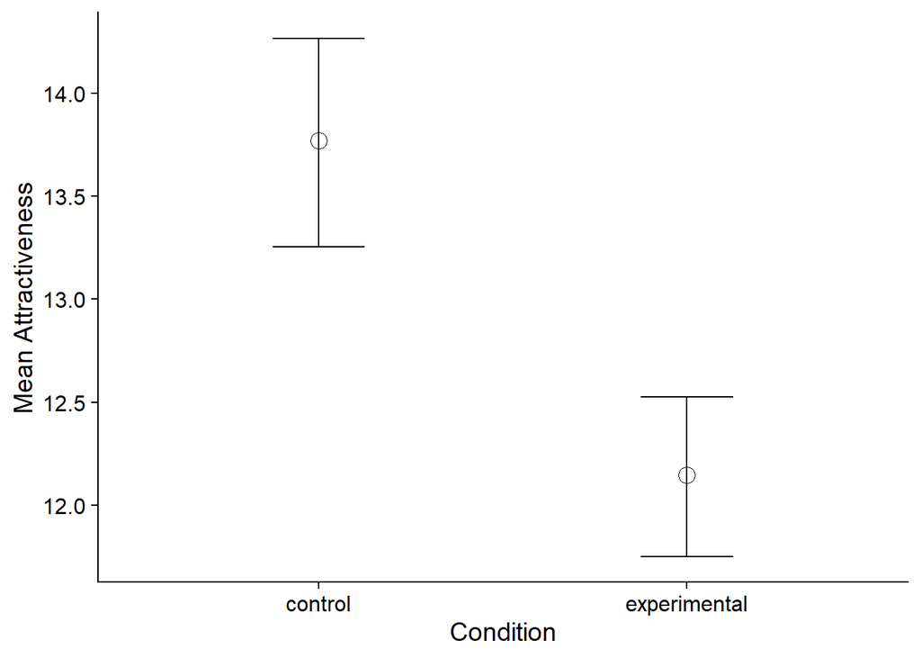

# Discussion

Our study showed results that suggested that a white frame results in a higher mean attractiveness rating of a man, compared to the same man in a red frame. Thus, making our hypothesis incorrect. It could be suggested that the population sample was too small and therefore is not representative of the global population, in future studies a larger sample size should be used to result in lower participant bias. It could also be suggested that the experiment itself was too simple resulting in demand characteristics from the participants as they may have tried to guess the true purpose of the experiment and changed their answers. However, there are several other problems with the lab style set up of our experiment which could have also contributed to the unexpected results. The photo used in the experiment was only of one man who was an ‘average’ looking and Caucasian with brown hair, thus nowhere near captured the variance of looks and features that people around the world have. Thus, the ecological validity of the study was very low. A study by Hesslinger et al (Hesslinger, 2015) supported our results as it suggested that red does not influence perceived attractiveness, but that the smartness of attire does. Men viewed in a suit instead of activewear were perceived to be higher in status and more attractive. The data was statistically significant in showing how style of clothing made a man seem more attractive, but their experiments found no statistically significant results suggesting that the colour red makes a man seem more attractive. This could suggest that there are many factors that influence what makes someone seem more desirable. Further suggesting that in order to understand how colour influences attraction it would be necessary to add other variables to compare against the colour variable. Colour-in-context theory (Elliot. J Andrew, 2012) suggests that colour in particular contexts influences how people act or perceive situations. In relation to attraction the colour red is often, but not always culturally associated with power and wealth, it would then follow that a person would then seem more attractive if surrounded by or wearing red (Elliot. J Andrew, 2012). However, group of empirical studies by Peperkoorn et al did not support the colour-in-context theory, adding to the suggestion that there is more to attraction than colour influence. With such variability in results from experiments on this topic it cannot be said as to how reliable colour-context-theory is (Elliot. J Andrew, 2012). In order to better understand how colour influences attraction, it needs to first be analysed between cultures as different colours have different meanings across different cultures so it cannot be assumed that one colour such as red would increase attraction globally.

# References

Bibliography Elliot, A. J. (2010). Red, Rank, and Romance in women viewing men. Journal of Experimental Psychology: General, 399-417. Elliot, A. J. (2013). The red-attractiveness effect, applying the ioannidis and trikalinos(2007b) test, and the broader scientific context: A reply to francis (2013). Journal of Experimental Psychology: General, 297-300. Elliot. J Andrew, M. A. (2012). Chapter 2 - Colour -in - context -theory . Advances in Experimental Social Psychology , 61-125 . Francis, G. (2013). Comment publication bias in Red, Rank, and Romance in women viewing men, by Elliot et al. (2010). Journal of Experimental Psychology: General, 292-296. Hesslinger, V. M. (2015). Men in red: A reexamination of the red-attractiveness effect. Psychonomic Bulletin and Review, 1142-1148. Peperkoorn, L. S. (2016). Revisiting the red effect on attractiveness and sexual receptivity: No effect of the color red on human mate preferences. Evolutionary Psychology, 1-13.